# Code-Through - Batch Reporting

Kurtis Merrill

```r
library(dplyr)
library(gender)
library(knitr)

source("utils.R")
```

# Introduction

Have you ever needed to create the same report repeatedly using different data? Instead of writing five separate reports, we can create one report template and use a batch script to generate reports automatically.

This tutorial will demonstrate how to use:

- R Markdown templates
- custom functions
- parameters
- batch processing

The data used in this demo is from ASU Employee Salary data from 2012 to 2025. We’ll be using it to compare academic positions of male and female employees. Once the template is set up for creating one report for one year, we can use the template to quickly produce any of the years we’d like.

# Project Workflow

The project consists of three files:

```
batch.R
    |
    +---- salary-report.rmd
                |
                +---- utils.R
```

The workflow is:

1. `batch.R` selects a data source.
2. `salary-report.rmd` loads and analyzes the data.
3. `utils.R` provides reusable helper functions.
4. An HTML report is generated automatically.

# Step 1: Create Helper Functions

Helper functions are stored in a file named `utils.R`. Functions help avoid repeating the same code in the template.

For example, this function extracts first names from employee records:

```r
get_first_name("Doe, Jane")
```

```
## [1] "Jane"
```

Output:

```r
[1] "Jane"
```

# Step 2: Load Functions

Functions can be loaded into a project using:

```r
source("utils.R")
```

This makes all the helper functions available within the report.

# Step 3: Load Data

Load your dataset. This example uses a link from a Google Sheets tab for 2020 salaries:

```r
URL <- "https://docs.google.com/spreadsheets/d/1RoiO9bfpbXowprWdZrgtYXG9_WuK3NFemwlvDGdym7E/export?gid=1335284952&format=csv"

d <- read.csv(URL)

head(d)
```

```
##   Calendar.Year                           Full.Name            Job.Description
## 1          2020                    ABBASI, Mohammad     Research/Lab Assistant
## 2          2020 ARQUIZA, Jose Maria Reynaldo Apollo                   Lecturer
## 3          2020                      Aaberg, Kelsea Student Support Specialist
## 4          2020                    Abadjivor, Enyah            Project Manager
## 5          2020                   Abayesu, Precious          Management Intern
## 6          2020                        Abbas, James            Assoc Professor
##           Department.Description      Salary FTE
## 1 Sch Biological & Hlth Sys Engr  $35,090.00 100
## 2 Sch Biological & Hlth Sys Engr  $71,400.00 100
## 3             Admission Services  $36,000.00 100
## 4                   CASGE  Tempe  $64,000.00 100
## 5 Health & Clinical Partnerships  $20,800.00  50
## 6 Sch Biological & Hlth Sys Engr $107,195.00 100
```

# Step 4: Clean and Prepare Data

Extract first names:

```r
d$first.name <- get_first_name(d$Full.Name)

head(
  d[, c("Full.Name", "first.name")]
)
```

```
##                             Full.Name first.name
## 1                    ABBASI, Mohammad   Mohammad
## 2 ARQUIZA, Jose Maria Reynaldo Apollo       Jose
## 3                      Aaberg, Kelsea     Kelsea
## 4                    Abadjivor, Enyah      Enyah
## 5                   Abayesu, Precious   Precious
## 6                        Abbas, James      James
```

Add gender classifications:

```r
d <- add_gender(d)

table(d$gender)
```

```
##
##    male  female uncoded
##    5218    6548     754
```

Standardize job titles:

```r
d <- add_titles(d)

table(d$title)
```

```
##
##      Full Professor Associate Professor Assistant Professor    Teaching Faculty
##                 662                 643                 488                1258
##          Researcher
##                 760
```

Convert salary values to numeric full-time equivalent salaries:

```r
d <- fix_salary(d)

summary(d$salary)
```

```
##    Min. 1st Qu.  Median    Mean 3rd Qu.    Max.
##      10   47855   61898   77692   90005 3500000
```

Demonstrate the salary formatting function:

```r
dollarize(123456)
```

```
## [1] "$123,456"
```

# Step 5: Create Analysis Sample

Select only academic faculty positions used in the report.

```r
d <- d %>%
  filter(title != "" & !is.na(title)) %>%
  filter(Department.Description %in% academic.units)

dim(d)
```

```
## [1] 2459   10
```

# Step 6: Select One Department

For demonstration purposes, we will focus on the Psychology department.

```r
d2 <- d %>%
  filter(Department.Description == "Psychology")

dim(d2)
```

```
## [1] 78 10
```

# Step 7: Create Salary Summary Table

Summarize salaries by academic rank and gender.

```r
t.salary <-
  d2 %>%
  group_by(title, gender) %>%
  summarize(
    q25 = quantile(salary, 0.25),
    q50 = quantile(salary, 0.50),
    q75 = quantile(salary, 0.75),
    n = n()
  ) %>%
  ungroup() %>%
  mutate(p = round(n / sum(n), 2))

t.salary
```

```
## # A tibble: 14 × 7
##    title               gender      q25     q50     q75     n     p
##    <fct>               <fct>     <dbl>   <dbl>   <dbl> <int> <dbl>
##  1 Full Professor      male    121920. 133778. 164629.    14  0.18
##  2 Full Professor      female  145685  161320  206856.     8  0.1
##  3 Full Professor      uncoded 116114. 118250  120386.     2  0.03
##  4 Associate Professor male     98000  106250  112619      9  0.12
##  5 Associate Professor female  108367  113215  121520      5  0.06
##  6 Associate Professor uncoded 111780  111780  111780      1  0.01
##  7 Assistant Professor female   92000   92750   93875      6  0.08
##  8 Assistant Professor uncoded  92000   92000   92000      1  0.01
##  9 Teaching Faculty    male     80702.  85175   88888.     4  0.05
## 10 Teaching Faculty    female   56762.  59167.  61322.     4  0.05
## 11 Teaching Faculty    uncoded  57192.  57795   58398.     2  0.03
## 12 Researcher          male     56352   60000   84443.     3  0.04
## 13 Researcher          female   50004   52251.  78000     17  0.22
## 14 Researcher          uncoded  90534  108289  126044      2  0.03
```

The summary includes:

- 25th percentile salary
- Median salary
- 75th percentile salary
- Number of faculty members
- Proportion of faculty by rank

# Step 8: Visualize Results

Create a graph comparing salaries by rank and gender.

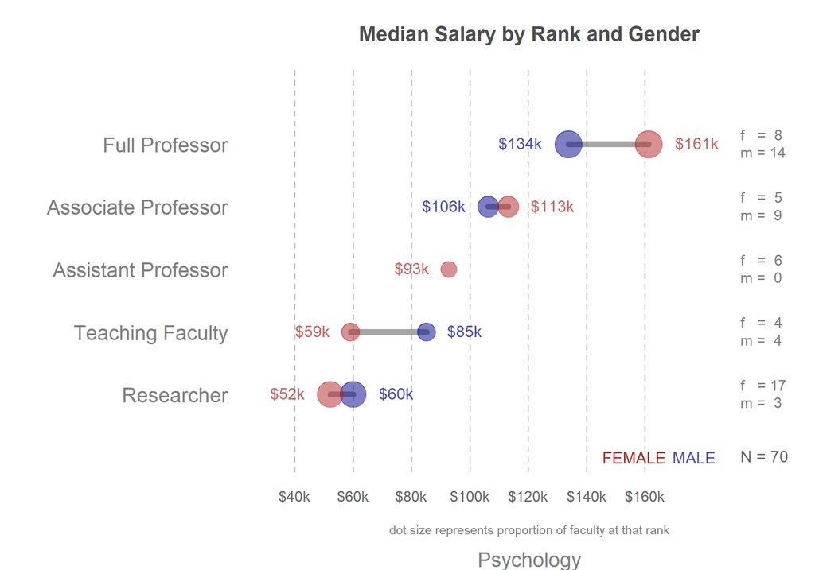

```r
build_graph(
  t.salary,
  unit = "Psychology"
)
```

# Step 9: Format and Display Salary Table

Convert salary values to readable currency format.

```r
t.salary$q25 <- dollarize(t.salary$q25)
t.salary$q50 <- dollarize(t.salary$q50)
t.salary$q75 <- dollarize(t.salary$q75)

knitr::kable(t.salary)
```

[output not shown]

# Step 10: Display Top Five Salaries

Identify the five highest-paid employees in the department.

```r
t.top5 <-
  d2 %>%
  arrange(desc(salary)) %>%
  select(
    Full.Name,
    Job.Description,
    salary
  ) %>%
  head(5)

t.top5$salary <- dollarize(t.top5$salary)

knitr::kable(t.top5)
```

| Full.Name | Job.Description | salary |
| --- | --- | --- |
| McNamara, Danielle | Professor | $227,000 |
| Chassin, Laurie | Regents Professor | $226,418 |
| Eisenberg, Nancy | Regents Professor | $200,336 |
| Mackinnon, David | Professor | $177,750 |
| Kenrick, Douglas | President’s Professor | $176,765 |

# Step 11: Create a Generic Report Template

Instead of creating separate reports manually, we can create a single reusable report template. The parameter is supplied by batch.R at the render stage, allowing the same report template to work with multiple years of data.

The template accepts an external parameter:

```yaml
params:
  url:
    value: x
```

The parameter is used to load data:

```r
URL <- params$url
d <- read.csv(URL)
```

This allows the same report to work with different datasets.

# Step 12: Batch Processing

The `rmarkdown::render()` function can generate reports automatically.

Example:

```r
url.2020 <- "data_url"

rmarkdown::render(
  input = "salary-report.rmd",
  output_file = "ASU-2020-Salary-Report.HTML",
  params = list(url = url.2020)
)
```

# Step 13: Generate Multiple Reports

The completed batch script generated:

```
ASU-2016-Salary-Report.HTML
ASU-2017-Salary-Report.HTML
ASU-2018-Salary-Report.HTML
ASU-2019-Salary-Report.HTML
ASU-2020-Salary-Report.HTML
```

Each report uses:

- the same template
- the same helper functions
- a different yearly dataset

# Conclusion:

Benefits of batch reporting include:

- Reduced duplicated code
- Easier maintenance
- Consistent report formatting
- Automated report generation
- Fewer opportunities for human error

A change made once to the report template automatically applies to all future reports. By combining custom functions, R Markdown documents, and `rmarkdown::render()`, one report template can generate many reports with different datasets.

This strategy is useful for:

- annual or monthly reports
- scheduled compliance reporting
- recurring data analysis projects